# Lab 10: Bayesian model selection and model averaging - Gaussian linear model

STA 602: Bayesian and Modern Statistics

Nov 28, 2022

**Due:** 12pm, Nov 29, 2022

# Housekeeping

## R/RStudio

You all should have R and RStudio installed on your computers by now. If you do not, first install the latest version of R here: https://cran.rstudio.com (remember to select the right installer for your operating system). Next, install the latest version of RStudio here: https://www.rstudio.com/products/rstudio/download/. Scroll down to the “Installers for Supported Platforms” section and find the right installer for your operating system.

## R Markdown

You are required to use R Markdown to type up this lab report. If you do not already know how to use R markdown, refer to Sakai “Resources/Lab” folder for a very basic R Markdown template as well as a list of resources to help you learn how to use R markdown and LaTex.

## Gradescope

You MUST submit both your .Rmd and .pdf files to Gradescope. Make sure to knit to pdf and not html; ask the TA about knitting to pdf if you cannot figure it out. Be sure to submit under the right assignment entry.

## Getting started

You will need the following R packages. If you do not already have them installed, please do so first using the `install.packages` function.

```r
require(lattice)
library(pls)
library(calibrate)
library(BAS)
library(BMA)
library(mvtnorm)
```

For this lab, you will need a data file. Download is from Sakai and make sure to save it in the same folder as the R script or R markdown file you are working from.

# In-lab Review on Bayesian model selection and BMA

# Data Example

For this lab, we will be looking at a health care data set. Health plans use many tools to try to control the cost of prescription medicines. For older drugs, generic substitutes that are the equivalent to name-brand drugs are available at considerable savings. Another tool that may lower costs is restricting drugs that the physician may prescribe. For example if three similar drugs for treating the same condition are available, a health plan may require the physician to prescribe only one of them, allowing the plan to negotiate discounts based on a higher volume of sales.

We have data from 29 health plans can be used to explore the effectiveness of these two strategies in controlling drug costs. The response is COST, the average cost of the prescriptions to the plan per day (in dollars).

```r
Data <- read.table("costs.txt",header=TRUE)[,-9]
head(Data)
```

```
##   COST RXPM GS RI COPAY AGE  F      MM
## 1  1.3  4.2 36 46  10.9  30 52 1158096
## 2  1.3  5.4 37 46   8.7  30 52 1049892
## 3  1.4  7.0 37 46   8.1  30 52   96168
## 4  1.2  7.1 40 24   5.9  29 53  407268
## 5  1.1  3.5 40 24   6.0  29 53   13224
## 6  1.2  7.2 46 22   5.0  29 52  303312
```

```r
dim(Data)
```

```
## [1] 29  8
```

Potential explanatory variables are:

- RXPM: Average number of prescriptions per member per year
- GS: Percent generic substitute used by the plan
- RI: Restrictiveness Index, from 0 (no restrictions) to 100 (total restrictions on the physician)
- COPAY: Average member copay on prescriptions
- AGE: Average member age
- F: percent female members
- MM: Member months, a measure of the size of the plan
- ID: an identifier for the name of the plan

## EDA

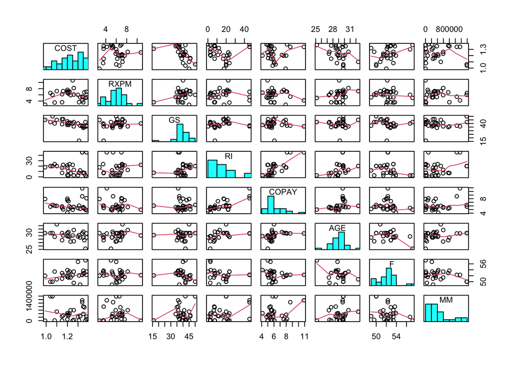

```r
# pairwise plots
panel.hist <- function(x, ...)
{
  usr <- par("usr"); on.exit(par(usr))
  par(usr = c(usr[1:2], 0, 1.5) )
  h <- hist(x, plot = FALSE)
  breaks <- h$breaks; nB <- length(breaks)
  y <- h$counts; y <- y/max(y)
  rect(breaks[-nB], 0, breaks[-1], y, col = "cyan", ...)
}
pairs((Data), panel=panel.smooth,diag.panel=panel.hist, cex.labels=1)
```

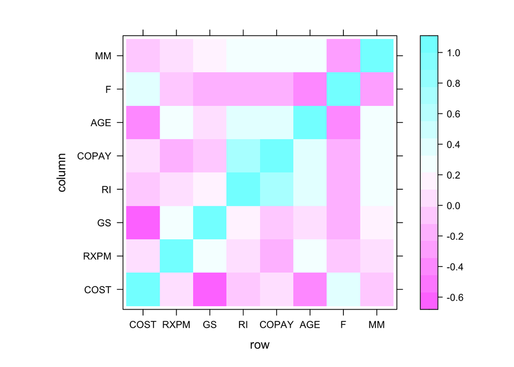

```r
# correlation
levelplot(cor(Data))
```

1. What do you notice from the EDA? Why we might want to use BMA for this data set?

## Linear Regression

Let’s first do linear regression on the data with all the predictors. We will use g-Prior with $g=n$ as discussed in class and in the textbook (codes are available on Sakai).

```r
# g-Prior: with g=n using full model
#Data summaries
n <- 29
p <- 8
g <- n
X <- cbind(1,as.matrix(Data[,c("RXPM","GS","RI","COPAY","AGE","F","MM")]))
colnames(X) <- c("Intercept", "RXPM","GS","RI","COPAY","AGE","F","MM")
Y <- matrix(Data$COST,ncol=1)

#Hyperparameters for the priors
beta_ols <- solve(t(X)%*%X)%*%t(X)%*%Y
SSR_beta_ols <- (t(Y - (X%*%(solve(t(X)%*%X))%*%t(X)%*%Y)))%*%(Y - (X%*%(solve(t(X)%*%X))%*%t(X)%*%Y))
sigma_ols <- SSR_beta_ols/(n-p)
#sigma_0_sq <- sigma_ols
sigma_0_sq <- 1/100
nu_0 <- 1

#set number of iterations
S <- 10000

#sample sigma_sq
nu_n <- nu_0 + n
Hg <- (g/(g+1))* X%*%solve(t(X)%*%X)%*%t(X)
SSRg <- t(Y)%*%(diag(1,nrow=n) - Hg)%*%Y
nu_n_sigma_n_sq <- nu_0*sigma_0_sq + SSRg
sigma_sq <- 1/rgamma(S,(nu_n/2),(nu_n_sigma_n_sq/2))

#sample beta
mu_n <- g*beta_ols/(g+1)
beta <- matrix(nrow=S,ncol=p)

for(s in 1:S){
  Sigma_n <- g*sigma_sq[s]*solve(t(X)%*%X)/(g+1)
  beta[s,] <- mvtnorm::rmvnorm(1,mu_n,Sigma_n)
}
```

```r
#posterior summaries
colnames(beta) <- colnames(X)
mean_beta <- apply(beta,2,mean)
round(mean_beta,4)
```

```
## Intercept      RXPM        GS        RI     COPAY       AGE         F        MM
##    1.8117    0.0217   -0.0110    0.0004    0.0137   -0.0364    0.0122    0.0000
```

```r
round(apply(beta,2,function(x) quantile(x,c(0.025,0.975))),4)
```

```
##       Intercept   RXPM     GS     RI  COPAY    AGE      F MM
## 2.5%       -2.5 -0.039 -0.027 -0.011 -0.088 -0.120 -0.043  0
## 97.5%       6.1  0.085  0.005  0.012  0.119  0.048  0.067  0
```

2. What do you observe from the linear regression results? Comment on the posterior mean and credible intervals. How many of the coefficients have posterior credible intervals which cover zero? What are the implications?

## Bayesian Model Selection and Averaging

In this section, we look at the marginal inclusion probability, model summary and posterior distribution of the coefficients under BMA.

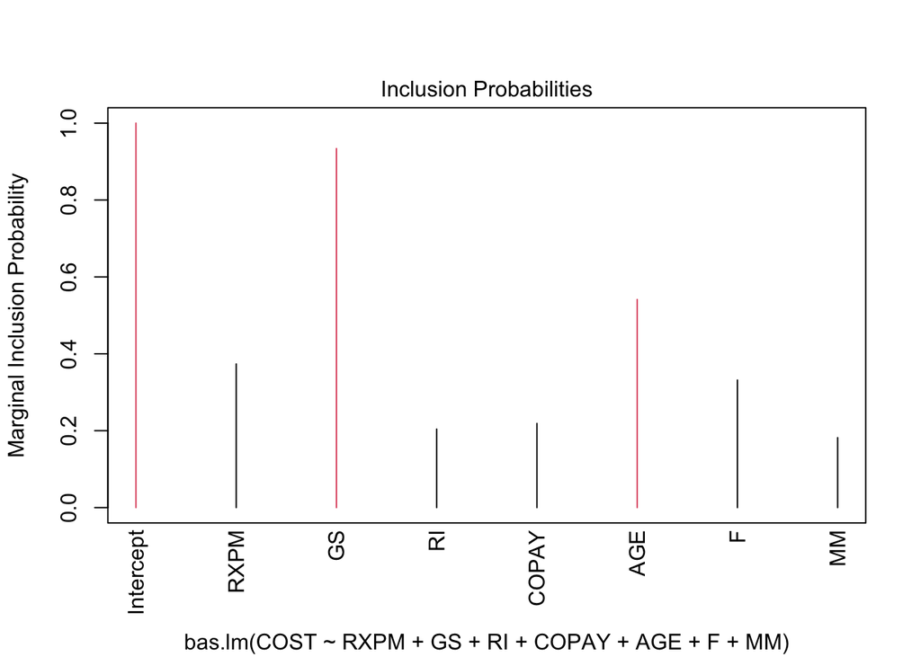

```r
Data_bas <- bas.lm(COST~RXPM+GS+RI+COPAY+AGE+F+MM, data=Data, prior="g-prior",alpha=n,
                    n.models=2^p, initprobs="Uniform")
plot(Data_bas,which=4)
```

```r
summary(Data_bas)
```

[output not shown]

```r
model_coef <- coef(Data_bas)
confint(model_coef)
```

```
##               2.5%   97.5%     beta
## Intercept  1.2e+00 1.3e+00  1.2e+00
## RXPM      -9.7e-06 3.4e-02  6.8e-03
## GS        -1.5e-02 0.0e+00 -9.8e-03
## RI        -1.1e-03 3.0e-03  2.1e-04
## COPAY     -6.9e-03 3.2e-02  2.6e-03
## AGE       -5.3e-02 0.0e+00 -1.7e-02
## F         -9.3e-04 2.8e-02  4.7e-03
## MM        -2.4e-08 6.7e-08  4.0e-09
## attr(,"Probability")
## [1] 0.95
## attr(,"class")
## [1] "confint.bas"
```

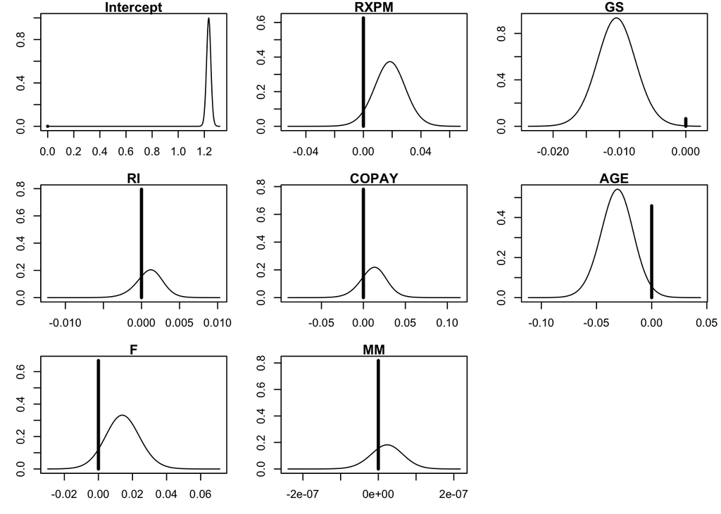

```r
par(mfrow=c(3,3),mar=c(3,3,1,1))
plot(coef(Data_bas), ask=T)
```

3. What do you learn from the BMA results? Which predictors are more likely to be significant towards predicting the response variable?

During EDA, we have noticed some potential outliers in the data. Bayesian tools can also help us in identifying outliers.

```r
Data_bma <- MC3.REG(Y, as.matrix(Data[, -1]),num.its=10000,outliers=TRUE,
                   M0.out=rep(FALSE, 29), outs.list=1:29, M0.var=rep(TRUE,7))
summary(Data_bma)
```

```
##
## Call:
## MC3.REG(all.y = Y, all.x = as.matrix(Data[, -1]), num.its = 10000,     M0.var = rep(TRUE, 7), M0.out = rep(FALSE, 29), outs.list = 1:29,     outliers = TRUE)
##
## Model parameters: PI = 0.1 K = 7 nu = 2.58 lambda = 0.28 phi = 2.85
##
##   5882  models were selected
##  Best  5  models (cumulative posterior probability =  0.2 ):
##
##            prob     model 1  model 2  model 3  model 4  model 5
## variables
##   RXPM     0.1481    .        .        .        .        .
##   GS       0.9999    x        x        x        x        x
##   RI       0.1601    .        .        .        .        x
##   COPAY    0.0710    .        .        .        .        .
##   AGE      0.5880    .        x        .        x        x
##   F        0.0786    .        .        .        .        .
##   MM       0.0658    .        .        .        .        .
## outliers
##   1        0.01047   .        .        .        .        .
##   2        0.01359   .        .        .        .        .
##   3        0.03687   .        .        .        .        .
##   4        0.00931   .        .        .        .        .
##   5        0.40053   .        .        .        x        x
##   6        0.01035   .        .        .        .        .
##   7        0.00843   .        .        .        .        .
##   8        0.01010   .        .        .        .        .
##   9        0.01109   .        .        .        .        .
##   10       0.32396   .        .        .        x        x
##   11       0.01193   .        .        .        .        .
##   12       0.30725   .        .        .        x        x
##   13       0.01033   .        .        .        .        .
##   14       0.00986   .        .        .        .        .
##   15       0.01050   .        .        .        .        .
##   16       0.00947   .        .        .        .        .
##   17       0.01227   .        .        .        .        .
##   18       0.01070   .        .        .        .        .
##   19       0.93383   x        x        x        x        x
##   20       0.00785   .        .        .        .        .
##   21       0.24824   .        .        .        x        x
##   22       0.01100   .        .        .        .        .
##   23       0.01345   .        .        .        .        .
##   24       0.03390   .        .        .        .        .
##   25       0.01590   .        .        .        .        .
##   26       0.00817   .        .        .        .        .
##   27       0.01313   .        .        .        .        .
##   28       0.16891   .        .        x        .        .
##   29       0.01656   .        .        .        .        .
##
## post prob           0.0669   0.0551   0.0319   0.0219   0.0212
```

4. Which plans are identified as likely to be outliers?
5. Remove the outliers in the data and rerun BMA. Generate the same summary statistics and graphs as above, comment on the your observations. Are the results different?

# Grading

Total 10 points. 10 > Excellent; 8 > Good; 6 > Fair; 0 > Poor; NA if no submission.

# Acknowledgement

This lab material makes reference to [STA 602 2020 Spring lecture on BMA](https://sta-602l-s20.github.io/Course-Website/slides/lec-slides/18-linear-regression-II.pdf).